# Campus Water Quality: E. coli and Total Coliform

## 7. Statistical Tests: Do Sites Differ?

With the full class dataset (all groups, all rounds), we have enough replication to test whether bacterial concentrations differ significantly among sites. We use both ANOVA on log-transformed values and Kruskal-Wallis as a non-parametric check.

### 7.1 Log-transform and assumption check

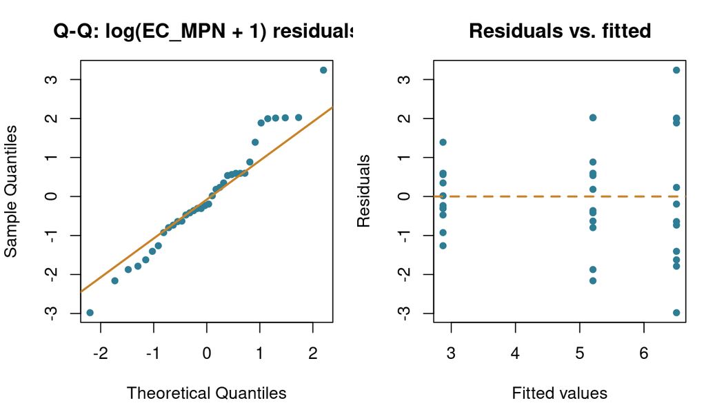

```r
MPN_data <- MPN_data %>%
  mutate(log_EC = log(EC_MPN + 1))

aov_ec <- aov(log_EC ~ Site_ID, data = MPN_data)

par(mfrow = c(1, 2), mar = c(4, 4, 3, 1))
qqnorm(residuals(aov_ec), main = "Q-Q: log(EC_MPN + 1) residuals",
       col = "#2e7d94", pch = 19, cex = 0.8)
qqline(residuals(aov_ec), col = "#c8832a", lwd = 2)
plot(fitted(aov_ec), residuals(aov_ec),
     xlab = "Fitted values", ylab = "Residuals",
     main = "Residuals vs. fitted",
     col = "#2e7d94", pch = 19, cex = 0.8)
abline(h = 0, col = "#c8832a", lwd = 2, lty = 2)
```

```r
par(mfrow = c(1, 1))
```

**📌 Why log-transform MPN data?** Raw MPN values are highly right-skewed — a few very high readings from storm events or turbid samples dominate the arithmetic mean. Taking log(MPN + 1) pulls outliers toward the bulk of the data, making the residuals more normally distributed and ANOVA assumptions more defensible. The “+1” prevents log(0) errors when a sample had no positive wells. This is the same reason the geometric mean is used instead of the arithmetic mean for regulatory assessments.

### 7.2 One-way ANOVA

```r
summary(aov_ec)
```

```
##             Df Sum Sq Mean Sq F value   Pr(>F)
## Site_ID      2  81.38   40.69   20.67 1.51e-06 ***
## Residuals   33  64.96    1.97
## ---
## Signif. codes:  0 '***' 0.001 '**' 0.01 '*' 0.05 '.' 0.1 ' ' 1
```

### 7.3 Tukey HSD post-hoc

```r
tukey_ec <- TukeyHSD(aov_ec)
print(tukey_ec)
```

```
##   Tukey multiple comparisons of means
##     95% family-wise confidence level
##
## Fit: aov(formula = log_EC ~ Site_ID, data = MPN_data)
##
## $Site_ID
##                                 diff        lwr        upr     p adj
## Pomona Bioswale-pHake Lake -3.634194 -5.0396383 -2.2287492 0.0000010
## Seal Court-pHake Lake      -1.300248 -2.7056927  0.1051964 0.0743409
## Seal Court-Pomona Bioswale  2.333946  0.9285011  3.7393901 0.0007757
```

```r
tukey_tbl <- broom::tidy(tukey_ec) %>%
  select(contrast, estimate, conf.low, conf.high, adj.p.value) %>%
  mutate(across(where(is.numeric), ~ round(.x, 3)))

tukey_tbl %>%
  kbl(
    caption   = "Tukey HSD pairwise comparisons — log(E. coli MPN + 1)",
    col.names = c("Comparison", "Difference (log scale)",
                  "Lower 95% CI", "Upper 95% CI", "Adj. p-value")
  ) %>%
  kable_styling(bootstrap_options = c("striped","hover"), full_width = FALSE) %>%
  row_spec(which(tukey_tbl$adj.p.value < 0.05),
           bold = TRUE, background = "#f1f8f1")
```

Tukey HSD pairwise comparisons — log(E. coli MPN + 1)

| Comparison | Difference (log scale) | Lower 95% CI | Upper 95% CI | Adj. p-value |
| --- | --- | --- | --- | --- |
| Pomona Bioswale-pHake Lake | -3.634 | -5.040 | -2.229 | 0.000 |
| Seal Court-pHake Lake | -1.300 | -2.706 | 0.105 | 0.074 |
| Seal Court-Pomona Bioswale | 2.334 | 0.929 | 3.739 | 0.001 |

### 7.4 Kruskal-Wallis (non-parametric check)

```r
kruskal.test(EC_MPN ~ Site_ID, data = MPN_data)
```

```
##
##  Kruskal-Wallis rank sum test
##
## data:  EC_MPN by Site_ID
## Kruskal-Wallis chi-squared = 22.066, df = 2, p-value = 1.616e-05
```

**💡 Do ANOVA and Kruskal-Wallis agree?** If both are significant (or both non-significant), you can be confident in the conclusion. If they disagree, examine the Q-Q plot carefully — a few extreme outliers can make ANOVA non-significant while Kruskal-Wallis detects a real difference. With MPN data from a class field exercise, Kruskal-Wallis is often the more appropriate primary test because the sample sizes per site are small and log-normality is hard to verify.

### 7.5 Total coliform: same tests

```r
aov_tc <- aov(log(TC_MPN + 1) ~ Site_ID, data = MPN_data)
summary(aov_tc)
```

```
##             Df Sum Sq Mean Sq F value   Pr(>F)
## Site_ID      2  83.54   41.77   24.21 3.38e-07 ***
## Residuals   33  56.94    1.73
## ---
## Signif. codes:  0 '***' 0.001 '**' 0.01 '*' 0.05 '.' 0.1 ' ' 1
```

```r
kruskal.test(TC_MPN ~ Site_ID, data = MPN_data)
```

```
##
##  Kruskal-Wallis rank sum test
##
## data:  TC_MPN by Site_ID
## Kruskal-Wallis chi-squared = 23.197, df = 2, p-value = 9.18e-06
```

## 8. Interpreting Your Results

### 8.1 Connecting statistics to site characteristics

Once you know which sites differ significantly, the next question is *why*. Use this framework:

```r
MPN_data %>%
  group_by(Site_ID) %>%
  summarise(
    n           = n(),
    gm_EC       = round(exp(mean(log(EC_MPN + 1))), 1),
    gm_TC       = round(exp(mean(log(TC_MPN + 1))), 1),
    EC_TC_ratio = round(gm_EC / gm_TC, 2),
    pct_diluted = round(100 * mean(dilution_factor > 1), 1),
    .groups     = "drop"
  ) %>%
  kbl(
    caption   = "Summary metrics for interpreting site contamination patterns",
    col.names = c("Site", "N", "Geom. mean EC", "Geom. mean TC",
                  "EC:TC ratio", "% samples diluted")
  ) %>%
  kable_styling(bootstrap_options = c("striped","hover"), full_width = FALSE)
```

Summary metrics for interpreting site contamination patterns

| Site | N | Geom. mean EC | Geom. mean TC | EC:TC ratio | % samples diluted |
| --- | --- | --- | --- | --- | --- |
| Pomona Bioswale | 12 | 17.7 | 24.0 | 0.74 | 0.0 |
| Seal Court | 12 | 182.3 | 174.7 | 1.04 | 33.3 |
| pHake Lake | 12 | 669.0 | 1000.8 | 0.67 | 50.0 |

**How to use the EC:TC ratio:**

- **EC:TC ratio close to 1.0** — nearly all coliforms are *E. coli*; contamination is predominantly fecal. Expected at pHake Lake (bird waste) and storm drains.
- **EC:TC ratio much less than 1.0** — many non-*E. coli* coliforms present; contamination includes environmental organisms from soil, plant material, or old biofilms. May be expected at the Bioswale, which filters through organic material.

### 8.2 Comparing your group’s results to the class

```r
# Replace "Group_1" and "Round_1" with your actual values
your_data <- MPN_data %>%
  filter(Group == "Group_1", Round == "Round_1")

your_data %>%
  select(Site_ID, Dilution, raw_TC, raw_EC, TC_MPN, EC_MPN) %>%
  kbl(caption = "Your group's corrected MPN values") %>%
  kable_styling(bootstrap_options = c("striped","hover"), full_width = FALSE)
```

[output not shown]

## 9. Summary

#### 💡 Key takeaways

- **E. coli is an indicator, not the only threat.** Its presence signals fecal contamination and the potential presence of a suite of harder-to-detect pathogens. Absence does not guarantee safety — it just means fecal contamination is below detection.
- **Dilution correction is mandatory.** A raw reading from a 1:10 diluted sample that is not multiplied by 10 systematically underestimates the true bacterial load by an order of magnitude. Always check the Dilution column before reporting any MPN value.
- **The “>2419.6” ceiling is a censored observation, not missing data.** Do not replace it with NA. Use 2419.6 as a lower bound and note it in your methods. These are the most contaminated samples in your dataset.
- **Log-transform before ANOVA; use geometric mean for summaries.** Both practices are required because MPN data is log-normally distributed. Reporting arithmetic means overstates typical exposure.
- **pHake Lake likely has the highest E. coli.** Resident waterfowl (Canada geese, mallards) deposit large quantities of fecal matter directly into the lake. This is not a sewage problem — it is a wildlife management and urban park design problem with different interventions.
- **The Bioswale is doing its job** if it shows lower concentrations than Seal Court stormwater inputs. Comparing upstream/downstream of the Bioswale would be a natural extension of this sampling design.

## References

IDEXX Laboratories. 2013. *Colilert and Quanti-Tray/2000 Procedure*. Westbrook, ME.

US EPA. 2012. *Recreational Water Quality Criteria*. EPA 820-F-12-058. Washington, DC.

California State Water Resources Control Board. 2022. *Water Quality Control Plan for the Inland Valleys Basin (Basin Plan)*. Region 8.

Rompré, A., et al. 2002. Detection and enumeration of coliforms in drinking water: current methods and emerging approaches. *Journal of Microbiological Methods* 49:31–54.

EA030 RTricks | Prof. Marc Los Huertos | Pomona College | Activity 19 | Back to index